# PEGASUS targeted microbial metabolites

Precion data

MHuang

5/3/2021

# 1. Data assembly

## 1.1. Phenotype/EMR data

```r
load(pheno_fname, verbose = T)
```

```
## Loading objects:
##   pheno
```

## 1.2. Microbial mets data

```r
link_id <- fread(link_id_fname)
link_id$SUBJ_ALIASID %in% pheno$Biobank_Subject_ID %>% table()
```

```
## .
## TRUE
## 1125
```

```r
setnames(link_id, "SUBJ_ALIASID", "Biobank_Subject_ID")

microb_mets <- read_xlsx(microb_mets_fname) %>% as.data.table()
setnames(microb_mets, gsub("[ ()/]", "_", colnames(microb_mets)))
microb_mets[, COMP_ID := str_c("X", seq(1, .N))]
setcolorder(microb_mets, "COMP_ID")
microb_mets_info <- microb_mets[, c(1:11)]
microb_mets_list <- microb_mets_info$COMP_ID

subj_cols <- colnames(microb_mets)[-c(2:11)]
microb_mets_dat <- microb_mets[, ..subj_cols] %>% as.data.frame()
rownames(microb_mets_dat) <- microb_mets_dat$COMP_ID
microb_mets_dat$COMP_ID <- NULL
microb_mets_dat <- t(microb_mets_dat) %>% as.data.frame() %>% rownames_to_column() %>% as.data.table()
setnames(microb_mets_dat, "rowname", "S_SAMPLEID")

microb_mets_dat[, (microb_mets_list) := lapply(.SD, as.character), .SDcols = microb_mets_list]
suppressWarnings(microb_mets_dat[, (microb_mets_list) := lapply(.SD, as.numeric), .SDcols = microb_mets_list])
microb_mets_dat <- merge(microb_mets_dat, link_id[, .(Biobank_Subject_ID, S_SAMPLEID)], by = "S_SAMPLEID")

mets_missing <- microb_mets_dat[, lapply(.SD, function(x) mean(is.na(x))), .SDcols = microb_mets_list] %>%
        t() %>% as.data.frame() %>% rownames_to_column()
setnames(mets_missing, c("COMP_ID", "pct_na_met"))
microb_mets_info <- merge(microb_mets_info, mets_missing, by = "COMP_ID")
microb_mets_info[, summary(pct_na_met)]
```

```
##     Min.  1st Qu.   Median     Mean  3rd Qu.     Max.
## 0.000000 0.001111 0.024889 0.263276 0.358667 0.998222
```

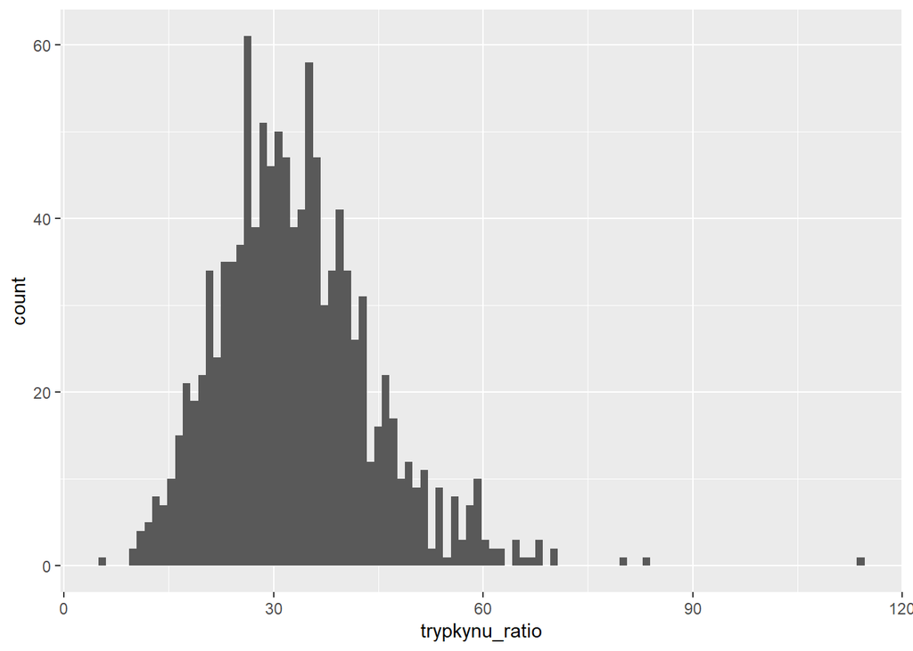

```r
microb_dat <- merge(pheno, microb_mets_dat, by = c("Biobank_Subject_ID"))
microb_dat[, ':='(trypkynu_ratio = X66 / X41)]
ggplot(microb_dat) + geom_histogram(aes(trypkynu_ratio), bins = 100)
```

```r
## Add indicators for platform & without MS2

microb_mets_info[, ':='(feature = COMP_ID,
                        tentative_annotation = Component_Name,
                        platform = "Targeted-microbial-mets",
                        wo_ms2 = 0,
                        med_feat = 0,
                        rt_min = NA,
                        mz = NA,
                        cv = NA,
                        skewness_post = NA)]
# The annotations are accurate - only duplicating for programing purpose
```

## 1.3. Apply exclusion

- _trim: subjects missing collection date / bmi / bmi >5yrs away from collection date & matched subjects removed
- _excl: further excluded subjects with the following comorbidities and matched subjects
  - COPD, A1AD, cystic fibrosis, bronchiectasis, chronic bronchitis, immuno deficiency

```r
stratum_to_rm <- microb_dat[is.na(Collect_Date) | is.na(bmi) | abs(bmi_timegap_y) > 5, unique(Stratum)]
stratum_to_rm <- c(stratum_to_rm, microb_dat[, .N, Stratum][N == 1, Stratum]); length(stratum_to_rm)
```

```
## [1] 50
```

```r
microb_dat_trim <- microb_dat[!(Stratum %in% stratum_to_rm), ]

comorb_excl <- microb_dat_trim[copd_5 == 1 | a1ad == 1 | cf == 1 | bronchiectasis == 1 | cbronchitis == 1 |
                                    immunodef == 1, unique(Stratum)]; length(comorb_excl)
```

```
## [1] 88
```

```r
microb_dat_excl <- microb_dat_trim[!(Stratum %in% comorb_excl), ]
```

# 2. Regression model functions

On features that passed QC with <= 50% missing

```r
feat_list <- c(microb_mets_info[pct_na_met <= missing_thld, feature], "trypkynu_ratio"); length(feat_list)
```

```
## [1] 55
```

```r
clogi_res_fnc <- function(outc, mets_list, dat, mets_info, add_covar = "",
                          first_cols = c("feature", "beta", "pval", "fdr_bh", "tentative_annotation",
                                         "wo_ms2", "med_feat", "rt_min", "mz", "platform", "or",
                                         "lower95", "upper95", "totaln", "casen", "pct_na_met"),
                          na_thld = missing_thld) {

        clogi_mdl_tmp <- function(met) {

                fit <- eval(parse(text = str_c("clogit(", outc, " ~ ", met, " + strata(Stratum)",
                                               add_covar, ", data = ", dat, ")")))

                coef <- summary(fit)$coefficients
                coef <- coef[rownames(coef) == met, ]

                confint <- summary(fit)$conf.int
                confint <- confint[rownames(confint) == met, -c(1:2)]

                totaln <- summary(fit)$n
                casen <- summary(fit)$nevent

                output <- t(c(outc, met, coef, confint, totaln, casen)) %>% as.data.table()
                colnames(output) <- c("outc", "feature", "beta", "or", "se", "zval", "pval",
                                      "lower95", "upper95", "totaln", "casen")
                output[, (colnames(output)[-c(1:2)]) := lapply(.SD, as.numeric), .SDcols = colnames(output)[-c(1:2)]]

                return(output)
        }

        res <- lapply(mets_list, function(x) {clogi_mdl_tmp(met = x)}) %>% rbindlist()

        eval(parse(text = str_c("mets_info <- copy(", mets_info, ")")))
        res <- merge(res,
                     mets_info[, .(feature, SUB_PATHWAY, rt_min, mz, tentative_annotation, wo_ms2, med_feat,
                                   platform, cv, pct_na_met, skewness_post)],
                     by = "feature", all.x = T)
        res[pct_na_met <= na_thld & feature != "Unknown", fdr_bh := p.adjust(pval, method = "BH")]

        setcolorder(res, first_cols)
        res <- res[order(pval)]
        return(res)
}

linreg_res_fnc <- function(expo, mets_list, dat, mets_info, add_covar = "",
                           first_cols = c("feature", "expo_linreg", "beta_linreg", "pval_linreg",
                                          "fdr_bh_linreg", "tentative_annotation", "wo_ms2", "med_feat",
                                          "rt_min", "mz", "platform", "pct_na_met"),
                           na_thld = missing_thld) {

        linear_mdl_tmp <- function(met) {

                fit <- eval(parse(text = str_c("lm(", met, " ~ ", expo, " + Age + race",
                                               add_covar, ", data = ", dat, ")")))

                coef <- summary(fit)$coefficients
                coef <- coef[rownames(coef) == expo, ]

                output <- t(c(expo, met, coef)) %>% as.data.table()
                colnames(output) <- c("expo_linreg", "feature", "beta_linreg", "se_linreg", "tval_linreg",
                                      "pval_linreg")
                output[, (colnames(output)[-c(1:2)]) := lapply(.SD, as.numeric), .SDcols = colnames(output)[-c(1:2)]]

                return(output)
        }

        res <- lapply(mets_list, function(x) {linear_mdl_tmp(met = x)}) %>% rbindlist()

        eval(parse(text = str_c("mets_info <- copy(", mets_info, ")")))
        res <- merge(res,
                     mets_info[, .(feature, SUB_PATHWAY, rt_min, mz, tentative_annotation, wo_ms2, med_feat,
                                   platform, cv, pct_na_met, skewness_post)],
                     by = "feature", all.x = T)
        res[pct_na_met <= na_thld & feature != "Unknown", fdr_bh_linreg := p.adjust(pval_linreg, method = "BH")]

        setcolorder(res, first_cols)
        res <- res[order(pval_linreg)]
        return(res)
}
```

# 3. Analyses accounting for matched strata

## 3.1. Compare excluding OCS around serum collection vs not

### 3.1.1. NOT excluding COPD, cystic fibrosis, bronchiectasis, chronic bronchitis, a1ad, immune deficiencies

```r
res_3_1_1_1 <- clogi_res_fnc(outc = "asthma_num",
                             mets_list = feat_list,
                             dat = "microb_dat_trim",
                             mets_info = "microb_mets_info",
                             add_covar = " + bmi")
# datatable(res_3_1_1_1[tentative_annotation != "Unknown"], filter = "top") %>%
#         formatSignif(columns = num_cols, digits = sig_digits)

dat_tmp <- microb_dat_trim[Stratum %in% microb_dat_trim[ocs_ard_serum_coll == 0, Stratum], ]
res_3_1_1_2 <- clogi_res_fnc(outc = "asthma_num",
                             mets_list = feat_list,
                             dat = "dat_tmp",
                             mets_info = "microb_mets_info",
                             add_covar = " + bmi")
# datatable(res_3_1_1_2[tentative_annotation != "Unknown"], filter = "top") %>%
#         formatSignif(columns = num_cols, digits = sig_digits)

res_3_1_1_1[tentative_annotation != "Unknown" & pval < alpha_thld/5, .N,
         feature %in% res_3_1_1_2[tentative_annotation != "Unknown" & pval < alpha_thld/5, feature]]
```

```
##    feature N
## 1:    TRUE 2
## 2:   FALSE 3
```

```r
res_3_1_1_2[tentative_annotation != "Unknown" & pval < alpha_thld/5, .N,
         feature %in% res_3_1_1_1[tentative_annotation != "Unknown" & pval < alpha_thld/5, feature]]
```

```
##    feature N
## 1:    TRUE 2
## 2:   FALSE 1
```

### 3.1.2. Excluding COPD, cystic fibrosis, bronchiectasis, chronic bronchitis, a1ad, immune deficiencies

```r
res_3_1_2_1 <- clogi_res_fnc(outc = "asthma_num",
                             mets_list = feat_list,
                             dat = "microb_dat_excl",
                             mets_info = "microb_mets_info",
                             add_covar = " + bmi")
# datatable(res_3_1_2_1[tentative_annotation != "Unknown"], filter = "top") %>%
#         formatSignif(columns = num_cols, digits = sig_digits)

dat_tmp <- microb_dat_excl[Stratum %in% microb_dat_excl[ocs_ard_serum_coll == 0, Stratum], ]
res_3_1_2_2 <- clogi_res_fnc(outc = "asthma_num",
                             mets_list = feat_list,
                             dat = "dat_tmp",
                             mets_info = "microb_mets_info",
                             add_covar = " + bmi")
# datatable(res_3_1_2_2[tentative_annotation != "Unknown"], filter = "top") %>%
#         formatSignif(columns = num_cols, digits = sig_digits)

res_3_1_2_1[tentative_annotation != "Unknown" & pval < alpha_thld/5, .N,
         feature %in% res_3_1_2_2[tentative_annotation != "Unknown" & pval < alpha_thld/5, feature]]
```

```
##    feature N
## 1:    TRUE 4
## 2:   FALSE 1
```

```r
res_3_1_2_2[tentative_annotation != "Unknown" & pval < alpha_thld/5, .N,
         feature %in% res_3_1_2_1[tentative_annotation != "Unknown" & pval < alpha_thld/5, feature]]
```

```
##    feature N
## 1:   FALSE 2
## 2:    TRUE 4
```

> Conclusion: excluding asthmatics with OCS within 10 days of serum collection made a small amount of differences in the number of annotated metabolites with p<0.01; will proceed without the exclusion

## 3.2. Compare excluding certain comorbidities vs not

Comorbidities excluded here: COPD, cystic fibrosis, bronchiectasis, chronic bronchitis, a1ad, immune deficiencies

```r
res_3_1_1_1[tentative_annotation != "Unknown" & pval < alpha_thld/5, .N,
         feature %in% res_3_1_2_1[tentative_annotation != "Unknown" & pval < alpha_thld/5, feature]]
```

```
##    feature N
## 1:    TRUE 3
## 2:   FALSE 2
```

```r
res_3_1_2_1[tentative_annotation != "Unknown" & pval < alpha_thld/5, .N,
         feature %in% res_3_1_1_1[tentative_annotation != "Unknown" & pval < alpha_thld/5, feature]]
```

```
##    feature N
## 1:    TRUE 3
## 2:   FALSE 2
```

```r
datatable(res_3_1_1_1[tentative_annotation != "Unknown"], filter = "top") %>%
        formatSignif(columns = num_cols, digits = sig_digits)
```

|  | feature | beta | pval | fdr_bh | tentative_annotation | wo_ms2 | med_feat | rt_min | mz | platform | or | lower95 | upper95 | totaln | casen | pct_na_met | outc | se | zval | SUB_PATHWAY | cv | skewness_post |
| --- | --- | --- | --- | --- | --- | --- | --- | --- | --- | --- | --- | --- | --- | --- | --- | --- | --- | --- | --- | --- | --- | --- |
| 1 | X15 | -0.056691909149593 | 0.000249547008785091 | 0.0134755384743949 | arginine | 0 | 0 |  |  | Targeted-microbial-mets | 0.94488513499167 | 0.9166510884576 | 0.973988826905236 | 1039 | 519 | 0.00177777777777778 | asthma_num | 0.0154780713490778 | -3.6627243712099 | polyamine metabolism |  |  |
| 2 | X33 | -1.36151543928724 | 0.000504083463376482 | 0.013610253511165 | indole-3-propionate | 0 | 0 |  |  | Targeted-microbial-mets | 0.256272117697802 | 0.118998361639341 | 0.551901701876908 | 1003 | 493 | 0.0355555555555556 | asthma_num | 0.391400107586569 | -3.47857706959393 | Tryptophan Metabolism |  |  |
| 3 | X49 | 47.2618465622522 | 0.00760645524567275 | 0.0958911670878642 | phenol glucuronide | 0 | 0 |  |  | Targeted-microbial-mets | 3.35396994484086e+20 | 283831.572850092 | 3.96330622345425e+35 | 643 | 318 | 0.376 | asthma_num | 17.7073204141165 | 2.66905694689832 | Phenylalanine and Tyrosine Metabolism |  |  |
| 4 | X34 | -0.853882638573583 | 0.00840256042476881 | 0.0958911670878642 | indoleacetate | 0 | 0 |  |  | Targeted-microbial-mets | 0.425758651696501 | 0.225618801273234 | 0.803436719242631 | 1041 | 520 | 0 | asthma_num | 0.323998701144028 | -2.63545080754508 | Tryptophan Metabolism |  |  |
| 5 | X26 | -17.3850099789495 | 0.00980301581163702 | 0.0958911670878642 | cinnamoylglycine | 0 | 0 |  |  | Targeted-microbial-mets | 2.81699514380208e-08 | 5.24891041984951e-14 | 0.0151183026675316 | 762 | 350 | 0.272 | asthma_num | 6.73132818309165 | -2.58270128956404 | Phenylalanine and Tyrosine Metabolism |  |  |
| 6 | X66 | -0.0601094650288054 | 0.0106545741208738 | 0.0958911670878642 | tryptophan | 0 | 0 |  |  | Targeted-microbial-mets | 0.941661448944637 | 0.89920778579415 | 0.986119446958953 | 1040 | 519 | 0.000888888888888889 | asthma_num | 0.0235370020247144 | -2.55382843429631 | Tryptophan Metabolism |  |  |
| 7 | X30 | 68.7430143830196 | 0.0142967967331111 | 0.0989063405433702 | imidazole propionate | 0 | 0 |  |  | Targeted-microbial-mets | 7.1566835776734e+29 | 930327.888254621 | 5.50538369080062e+53 | 726 | 387 | 0.306666666666667 | asthma_num | 28.0615982976436 | 2.44971842494061 | Histidine Metabolism |  |  |
| 8 | X62 | -3.05349202481287 | 0.0146527911916104 | 0.0989063405433702 | serotonin | 0 | 0 |  |  | Targeted-microbial-mets | 0.0471938342692196 | 0.00406476578624278 | 0.547942516286851 | 1039 | 519 | 0.00177777777777778 | asthma_num | 1.25099601285034 | -2.44084872649244 | Tryptophan Metabolism |  |  |
| 9 | X8 | 2.25726005798191 | 0.0225836455605338 | 0.135501873363203 | 4-hydroxyphenylacetate | 0 | 0 |  |  | Targeted-microbial-mets | 9.5568679967402 | 1.37326235284031 | 66.50857770783 | 1001 | 506 | 0.0391111111111111 | asthma_num | 0.989850264980555 | 2.28040557025689 | Phenylalanine and Tyrosine Metabolism |  |  |
| 10 | X3 | -63.1741003474313 | 0.0296875607374355 | 0.142521697975998 | 3-hydroxybenzoate | 0 | 0 |  |  | Targeted-microbial-mets | 3.66299916705348e-28 | 6.78420466768465e-53 | 0.00197776505206966 | 856 | 410 | 0.178666666666667 | asthma_num | 29.0557953938156 | -2.17423407245212 | Dietary Aromatic Compounds |  |  |

[output cut: 44 more lines]

```r
datatable(res_3_1_2_1[tentative_annotation != "Unknown"], filter = "top") %>%
        formatSignif(columns = num_cols, digits = sig_digits)
```

|  | feature | beta | pval | fdr_bh | tentative_annotation | wo_ms2 | med_feat | rt_min | mz | platform | or | lower95 | upper95 | totaln | casen | pct_na_met | outc | se | zval | SUB_PATHWAY | cv | skewness_post |
| --- | --- | --- | --- | --- | --- | --- | --- | --- | --- | --- | --- | --- | --- | --- | --- | --- | --- | --- | --- | --- | --- | --- |
| 1 | X15 | -0.0586487513780099 | 0.000586440076235825 | 0.0316677641167345 | arginine | 0 | 0 |  |  | Targeted-microbial-mets | 0.94303795177102 | 0.912027096828306 | 0.975103241530006 | 862 | 431 | 0.00177777777777778 | asthma_num | 0.017059918855842 | -3.43780951560189 | polyamine metabolism |  |  |
| 2 | X33 | -1.19019801421044 | 0.002736274080847 | 0.063757307841278 | indole-3-propionate | 0 | 0 |  |  | Targeted-microbial-mets | 0.304161029897109 | 0.139618527637534 | 0.662619307576764 | 834 | 413 | 0.0355555555555556 | asthma_num | 0.397274322347319 | -2.99590974613734 | Tryptophan Metabolism |  |  |
| 3 | X49 | 77.063954618258 | 0.00383803649623431 | 0.063757307841278 | phenol glucuronide | 0 | 0 |  |  | Targeted-microbial-mets | 2.9406967687781e+33 | 60224091577.543 | 1.43591995485187e+56 | 534 | 268 | 0.376 | asthma_num | 26.6548858697494 | 2.89117556138996 | Phenylalanine and Tyrosine Metabolism |  |  |
| 4 | X52 | 0.470714874096098 | 0.00472276354379837 | 0.063757307841278 | phenylacetylglutamine | 0 | 0 |  |  | Targeted-microbial-mets | 1.60113839655193 | 1.15508960202327 | 2.21943315949029 | 862 | 432 | 0.00266666666666667 | asthma_num | 0.166603548941549 | 2.82535922605852 | Phenylalanine and Tyrosine Metabolism |  |  |
| 5 | X62 | -3.58958948651672 | 0.00935291649022142 | 0.0948209010561549 | serotonin | 0 | 0 |  |  | Targeted-microbial-mets | 0.0276096622357758 | 0.00184236202906674 | 0.413758770940242 | 863 | 432 | 0.00177777777777778 | asthma_num | 1.38120769259113 | -2.59887742138382 | Tryptophan Metabolism |  |  |
| 6 | X30 | 97.9707999359615 | 0.0105356556729061 | 0.0948209010561549 | imidazole propionate | 0 | 0 |  |  | Targeted-microbial-mets | 3.53327792319246e+42 | 8789653991.88496 | 1.42031220956425e+75 | 595 | 314 | 0.306666666666667 | asthma_num | 38.3037440198403 | 2.55773430099197 | Histidine Metabolism |  |  |
| 7 | X47 | 3.24460307376795 | 0.0149549420719726 | 0.115366695983789 | p-cresol glucuronide | 0 | 0 |  |  | Targeted-microbial-mets | 25.6515262755854 | 1.8801188827534 | 349.978294619019 | 837 | 416 | 0.0311111111111111 | asthma_num | 1.33332453250742 | 2.43346836772457 | Phenylalanine and Tyrosine Metabolism |  |  |
| 8 | X37 | 0.323362576219233 | 0.0207750815933538 | 0.140231800755138 | indoxyl sulfate | 0 | 0 |  |  | Targeted-microbial-mets | 1.38176625567691 | 1.05047485795782 | 1.81753801232248 | 861 | 430 | 0.00444444444444444 | asthma_num | 0.139859849859573 | 2.31204721400678 | Tryptophan Metabolism |  |  |
| 9 | X54 | -0.0718692726741882 | 0.0299634484672207 | 0.152124270870421 | phenylalanine | 0 | 0 |  |  | Targeted-microbial-mets | 0.930652549578363 | 0.872175059387166 | 0.993050831613189 | 864 | 432 | 0 | asthma_num | 0.0331107341164133 | -2.17057321717799 | Phenylalanine and Tyrosine Metabolism |  |  |
| 10 | X3 | -69.5688241688809 | 0.0312029088490979 | 0.152124270870421 | 3-hydroxybenzoate | 0 | 0 |  |  | Targeted-microbial-mets | 6.1184800873187e-31 | 1.99997406118579e-58 | 0.00187181420526622 | 704 | 341 | 0.178666666666667 | asthma_num | 32.2903775339305 | -2.15447540357119 | Dietary Aromatic Compounds |  |  |

[output cut: 44 more lines]

> Conclusion: will proceed with excluding these conditions (res_3_1_2_1)

## 3.3. Adjusted for BMI & certain comorbities

Excluding COPD, cystic fibrosis, bronchiectasis, chronic bronchitis, alpha-1-antitrypsin deficiency, and immune deficiencies Adjusting for pulmonary hypertension, allergic rhinitis, congestive heart failure, gerd

```r
res_3_3 <- clogi_res_fnc(outc = "asthma_num",
                         mets_list = feat_list,
                         dat = "microb_dat_excl",
                         mets_info = "microb_mets_info",
                         add_covar = " + bmi + pulhtn + arhinitis + chf + gerd")

res_3_1_2_1[tentative_annotation != "Unknown" & pval < alpha_thld/5, .N,
         feature %in% res_3_3[tentative_annotation != "Unknown" & pval < alpha_thld/5, feature]]
```

```
##    feature N
## 1:    TRUE 2
## 2:   FALSE 3
```

```r
res_3_3[tentative_annotation != "Unknown" & pval < alpha_thld/5, .N,
         feature %in% res_3_1_2_1[tentative_annotation != "Unknown" & pval < alpha_thld/5, feature]]
```

```
##    feature N
## 1:   FALSE 4
## 2:    TRUE 2
```

> Conclusion: will proceed with not adjusting for pulmonary hypertension, allergic rhinitis, congestive heart failure, gerd

# 4. Association with ICS # prescriptions in all asthmatics

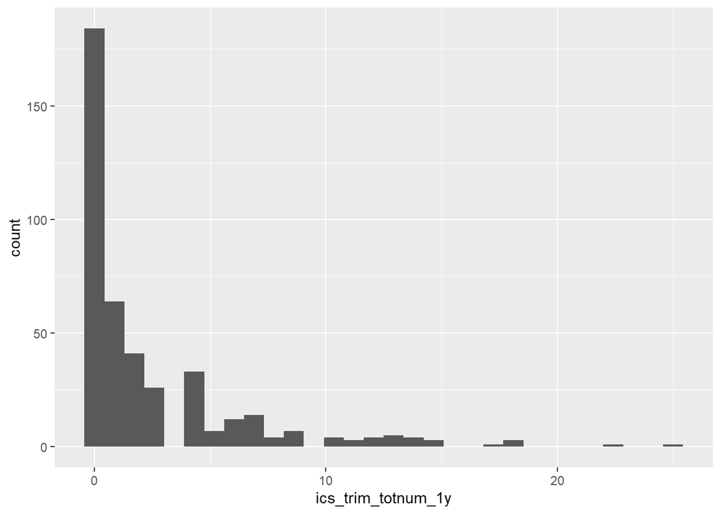

```r
dat_tmp <- microb_dat_excl[asthma_num == 1, ]
ggplot(dat_tmp) + geom_histogram(aes(ics_trim_totnum_1y), bins = 30)
```

```r
# dat_tmp[, ics_trim_totnum_1y_ind := case_when(ics_trim_totnum_1y == 0 ~ 0,
#                                               ics_trim_totnum_1y > 1 ~ 1)]
res_ics <- linreg_res_fnc(expo = "ics_trim_totnum_1y",
                          mets_list = feat_list,
                          dat = "dat_tmp",
                          mets_info = "microb_mets_info",
                          add_covar = " + Gender + bmi")

res_overall <- merge(res_3_1_2_1,
                     res_ics[, .(feature, expo_linreg, beta_linreg, pval_linreg, fdr_bh_linreg)],
                     by = "feature")
res_overall <- res_overall[order(pval)][, subgroup := "overall"] %>% setcolorder(., "subgroup")

display_cols <- c("subgroup", "feature", "tentative_annotation", "SUB_PATHWAY", "med_feat", "platform", "beta", "pval", "fdr_bh",
                  "or", "lower95", "upper95", "expo_linreg", "beta_linreg", "pval_linreg", "fdr_bh_linreg")
datatable(res_overall[tentative_annotation != "Unknown", ..display_cols], filter = "top") %>%
        formatSignif(columns = c("beta", "pval", "fdr_bh", "or", "lower95", "upper95",
                                 "beta_linreg", "pval_linreg", "fdr_bh_linreg"), digits = sig_digits)
```

|  | subgroup | feature | tentative_annotation | SUB_PATHWAY | med_feat | platform | beta | pval | fdr_bh | or | lower95 | upper95 | expo_linreg | beta_linreg | pval_linreg | fdr_bh_linreg |
| --- | --- | --- | --- | --- | --- | --- | --- | --- | --- | --- | --- | --- | --- | --- | --- | --- |
| 1 | overall | X15 | arginine | polyamine metabolism | 0 | Targeted-microbial-mets | -0.0586487513780099 | 0.000586440076235825 | 0.0316677641167345 | 0.94303795177102 | 0.912027096828306 | 0.975103241530006 | ics_trim_totnum_1y | -0.0371748861487426 | 0.48503693403429 | 0.904070456347838 |
| 2 | overall | X33 | indole-3-propionate | Tryptophan Metabolism | 0 | Targeted-microbial-mets | -1.19019801421044 | 0.002736274080847 | 0.063757307841278 | 0.304161029897109 | 0.139618527637534 | 0.662619307576764 | ics_trim_totnum_1y | 0.000650791333634193 | 0.763913777711218 | 0.904070456347838 |
| 3 | overall | X49 | phenol glucuronide | Phenylalanine and Tyrosine Metabolism | 0 | Targeted-microbial-mets | 77.063954618258 | 0.00383803649623431 | 0.063757307841278 | 2.9406967687781e+33 | 60224091577.543 | 1.43591995485187e+56 | ics_trim_totnum_1y | -9.34806824681016e-05 | 0.725518607105806 | 0.904070456347838 |
| 4 | overall | X52 | phenylacetylglutamine | Phenylalanine and Tyrosine Metabolism | 0 | Targeted-microbial-mets | 0.470714874096098 | 0.00472276354379837 | 0.063757307841278 | 1.60113839655193 | 1.15508960202327 | 2.21943315949029 | ics_trim_totnum_1y | 0.00514997333637021 | 0.553451431976423 | 0.904070456347838 |
| 5 | overall | X62 | serotonin | Tryptophan Metabolism | 0 | Targeted-microbial-mets | -3.58958948651672 | 0.00935291649022142 | 0.0948209010561549 | 0.0276096622357758 | 0.00184236202906674 | 0.413758770940242 | ics_trim_totnum_1y | 0.000638519511221245 | 0.346689940319476 | 0.904070456347838 |
| 6 | overall | X30 | imidazole propionate | Histidine Metabolism | 0 | Targeted-microbial-mets | 97.9707999359615 | 0.0105356556729061 | 0.0948209010561549 | 3.53327792319246e+42 | 8789653991.88496 | 1.42031220956425e+75 | ics_trim_totnum_1y | 0.000156017558901898 | 0.0106104587891023 | 0.424610067079291 |
| 7 | overall | X47 | p-cresol glucuronide | Phenylalanine and Tyrosine Metabolism | 0 | Targeted-microbial-mets | 3.24460307376795 | 0.0149549420719726 | 0.115366695983789 | 25.6515262755854 | 1.8801188827534 | 349.978294619019 | ics_trim_totnum_1y | 0.000459663539608944 | 0.614907767739379 | 0.904070456347838 |
| 8 | overall | X37 | indoxyl sulfate | Tryptophan Metabolism | 0 | Targeted-microbial-mets | 0.323362576219233 | 0.0207750815933538 | 0.140231800755138 | 1.38176625567691 | 1.05047485795782 | 1.81753801232248 | ics_trim_totnum_1y | -0.0110832594470006 | 0.482274594953039 | 0.904070456347838 |
| 9 | overall | X54 | phenylalanine | Phenylalanine and Tyrosine Metabolism | 0 | Targeted-microbial-mets | -0.0718692726741882 | 0.0299634484672207 | 0.152124270870421 | 0.930652549578363 | 0.872175059387166 | 0.993050831613189 | ics_trim_totnum_1y | 0.034819071304754 | 0.221666340577112 | 0.904070456347838 |
| 10 | overall | X3 | 3-hydroxybenzoate | Dietary Aromatic Compounds | 0 | Targeted-microbial-mets | -69.5688241688809 | 0.0312029088490979 | 0.152124270870421 | 6.1184800873187e-31 | 1.99997406118579e-58 | 0.00187181420526622 | ics_trim_totnum_1y | 3.08981176708327e-05 | 0.367770931364114 | 0.904070456347838 |

[output cut: 44 more lines]

```r
## Save results

saveRDS(res_overall, file = here(res_dir, "res_overall_microb.rds"))
```

# 5. Subgroup analyses

## 5.1. Subgroup by gender

### 5.1.1. Female

```r
## Asthmatics vs controls

dat_tmp1 <- microb_dat_excl[Gender == "F", ]
res_5_1_1 <- clogi_res_fnc(outc = "asthma_num",
                           mets_list = feat_list,
                           dat = "dat_tmp1",
                           mets_info = "microb_mets_info",
                           add_covar = " + bmi")
res_5_1_1[tentative_annotation != "Unknown" & pval < alpha_thld/5, .N,
          feature %in% res_overall[tentative_annotation != "Unknown" & pval < alpha_thld/5, feature]]
```

```
##    feature N
## 1:    TRUE 2
## 2:   FALSE 1
```

```r
res_5_1_1 <- res_5_1_1[, subgroup := "female"] %>% setcolorder(., "subgroup")


## Association with ICS # prescription in asthmatics

dat_tmp2 <- microb_dat_excl[Gender == "F" & asthma_num == 1, ]
res_5_1_1_ics <- linreg_res_fnc(expo = "ics_trim_totnum_1y",
                                mets_list = feat_list,
                                dat = "dat_tmp2",
                                mets_info = "microb_mets_info",
                                add_covar = " + bmi")
res_female <- merge(res_5_1_1,
                    res_5_1_1_ics[, .(feature, expo_linreg, beta_linreg, pval_linreg, fdr_bh_linreg)],
                    by = "feature")


## Save results

saveRDS(res_female, file = here(res_dir, "res_female_microb.rds"))
```

### 5.1.2. Male

```r
## Asthmatics vs controls

dat_tmp1 <- microb_dat_excl[Gender == 'M', ]
res_5_1_2 <- clogi_res_fnc(outc = "asthma_num",
                           mets_list = feat_list,
                           dat = "dat_tmp1",
                           mets_info = "microb_mets_info",
                           add_covar = " + bmi")
res_5_1_2[tentative_annotation != "Unknown" & pval < alpha_thld/5, .N,
          feature %in% res_3_1_2_1[tentative_annotation != "Unknown" & pval < alpha_thld/5, feature]]
```

```
##    feature N
## 1:   FALSE 2
```

```r
res_5_1_2 <- res_5_1_2[, subgroup := "male"] %>% setcolorder(., "subgroup")


## Association with ICS # prescription in asthmatics

dat_tmp2 <- microb_dat_excl[Gender == "M" & asthma_num == 1, ]
res_5_1_2_ics <- linreg_res_fnc(expo = "ics_trim_totnum_1y",
                                mets_list = feat_list,
                                dat = "dat_tmp2",
                                mets_info = "microb_mets_info",
                                add_covar = " + bmi")
res_male <- merge(res_5_1_2,
                  res_5_1_2_ics[, .(feature, expo_linreg, beta_linreg, pval_linreg, fdr_bh_linreg)],
                  by = "feature")


## Save results

saveRDS(res_male, file = here(res_dir, "res_male_microb.rds"))
```

## 5.2. Subgroup by ICS use in 1 year before collection

### 5.2.1. ICS # prescription > 0

```r
## Asthmatics vs controls

dat_tmp1 <- microb_dat_excl[Stratum %in% microb_dat_excl[asthma_num == 1 & ics_trim_totnum_1y > 0, Stratum], ]
res_5_2_1 <- clogi_res_fnc(outc = "asthma_num",
                           mets_list = feat_list,
                           dat = "dat_tmp1",
                           mets_info = "microb_mets_info",
                           add_covar = " + bmi")
res_5_2_1[tentative_annotation != "Unknown" & pval < alpha_thld/5, .N,
          feature %in% res_overall[tentative_annotation != "Unknown" & pval < alpha_thld/5, feature]]
```

```
## Empty data.table (0 rows and 2 cols): feature,N
```

```r
res_5_2_1 <- res_5_2_1[, subgroup := "ics_1y_prior_yes"] %>% setcolorder(., "subgroup")


## Association with ICS # prescription in asthmatics

dat_tmp2 <- microb_dat_excl[ics_trim_totnum_1y > 0 & asthma_num == 1, ]
res_5_2_1_ics <- linreg_res_fnc(expo = "ics_trim_totnum_1y",
                                mets_list = feat_list,
                                dat = "dat_tmp2",
                                mets_info = "microb_mets_info",
                                add_covar = " + Gender + bmi")
res_ics_1y_y <- merge(res_5_2_1,
                      res_5_2_1_ics[, .(feature, expo_linreg, beta_linreg, pval_linreg, fdr_bh_linreg)],
                      by = "feature")


## Save results

saveRDS(res_ics_1y_y, file = here(res_dir, "res_ics_1y_y_microb.rds"))
```

### 5.2.2. ICS # prescription == 0

```r
## Asthmatics vs controls

dat_tmp1 <- microb_dat_excl[Stratum %in% microb_dat_excl[asthma_num == 1 & ics_trim_totnum_1y == 0, Stratum], ]
res_5_2_2 <- clogi_res_fnc(outc = "asthma_num",
                           mets_list = feat_list,
                           dat = "dat_tmp1",
                           mets_info = "microb_mets_info",
                           add_covar = " + bmi")
res_5_2_2[tentative_annotation != "Unknown" & pval < alpha_thld/5, .N,
          feature %in% res_overall[tentative_annotation != "Unknown" & pval < alpha_thld/5, feature]]
```

```
##    feature N
## 1:    TRUE 3
```

```r
res_5_2_2 <- res_5_2_2[, subgroup := "ics_1y_prior_no"] %>% setcolorder(., "subgroup")


## Save results

res_ics_1y_n <- res_5_2_2[, ':='(expo_linreg = NA, beta_linreg = NA, pval_linreg = NA, fdr_bh_linreg = NA)]
saveRDS(res_ics_1y_n, file = here(res_dir, "res_ics_1y_n_microb.rds"))
```

## 5.3. Subgroup by eosinophil count

### 5.3.1. EOS >= 0.3 K/uL

```r
## Asthmatics vs controls

dat_tmp1 <- microb_dat_excl[Stratum %in% microb_dat_excl[asthma_num == 1 & eos >= 0.3, Stratum], ]
res_5_3_1 <- clogi_res_fnc(outc = "asthma_num",
                           mets_list = feat_list,
                           dat = "dat_tmp1",
                           mets_info = "microb_mets_info",
                           add_covar = " + bmi")
res_5_3_1[tentative_annotation != "Unknown" & pval < alpha_thld/5, .N,
          feature %in% res_overall[tentative_annotation != "Unknown" & pval < alpha_thld/5, feature]]
```

```
## Empty data.table (0 rows and 2 cols): feature,N
```

```r
res_5_3_1 <- res_5_3_1[, subgroup := "eos_high_300"] %>% setcolorder(., "subgroup")


## Association with ICS # prescription in asthmatics

dat_tmp2 <- microb_dat_excl[asthma_num == 1 & eos >= 0.3, ]
res_5_3_1_ics <- linreg_res_fnc(expo = "ics_trim_totnum_1y",
                                mets_list = feat_list,
                                dat = "dat_tmp2",
                                mets_info = "microb_mets_info",
                                add_covar = " + Gender + bmi")
res_eos_high <- merge(res_5_3_1,
                      res_5_3_1_ics[, .(feature, expo_linreg, beta_linreg, pval_linreg, fdr_bh_linreg)],
                      by = "feature")


## Save results

saveRDS(res_eos_high, file = here(res_dir, "res_eos_high_microb.rds"))
```

### 5.3.2. EOS < 0.3 K/uL

```r
## Asthmatics vs controls

dat_tmp1 <- microb_dat_excl[Stratum %in% microb_dat_excl[asthma_num == 1 & eos < 0.3, Stratum], ]
res_5_3_2 <- clogi_res_fnc(outc = "asthma_num",
                           mets_list = feat_list,
                           dat = "dat_tmp1",
                           mets_info = "microb_mets_info",
                           add_covar = " + bmi")
res_5_3_2[tentative_annotation != "Unknown" & pval < alpha_thld/5, .N,
          feature %in% res_overall[tentative_annotation != "Unknown" & pval < alpha_thld/5, feature]]
```

```
##    feature N
## 1:    TRUE 4
```

```r
res_5_3_2 <- res_5_3_2[, subgroup := "eos_low_300"] %>% setcolorder(., "subgroup")


## Association with ICS # prescription in asthmatics

dat_tmp2 <- microb_dat_excl[asthma_num == 1 & eos < 0.3, ]
res_5_3_2_ics <- linreg_res_fnc(expo = "ics_trim_totnum_1y",
                                mets_list = feat_list,
                                dat = "dat_tmp2",
                                mets_info = "microb_mets_info",
                                add_covar = " + Gender + bmi")
res_eos_low <- merge(res_5_3_2,
                     res_5_3_2_ics[, .(feature, expo_linreg, beta_linreg, pval_linreg, fdr_bh_linreg)],
                     by = "feature")


## Save results

saveRDS(res_eos_low, file = here(res_dir, "res_eos_low_microb.rds"))
```

## 5.4. Subgroup by asthma exacerbation == 0 in 1 year before collection

### 5.4.1. Exacerbation count > 0

```r
## Asthmatics vs controls

dat_tmp1 <- microb_dat_excl[Stratum %in% microb_dat_excl[asthma_num == 1 &
                                                                 asthma_exacerbation_trim_totnum_1y > 0, Stratum], ]
res_5_4_1 <- clogi_res_fnc(outc = "asthma_num",
                           mets_list = feat_list,
                           dat = "dat_tmp1",
                           mets_info = "microb_mets_info",
                           add_covar = " + bmi")
res_5_4_1[tentative_annotation != "Unknown" & pval < alpha_thld/5, .N,
          feature %in% res_overall[tentative_annotation != "Unknown" & pval < alpha_thld/5, feature]]
```

```
## Empty data.table (0 rows and 2 cols): feature,N
```

```r
res_5_4_1 <- res_5_4_1[, subgroup := "exacerbation_1y_prior_yes"] %>% setcolorder(., "subgroup")


## Association with ICS # prescription in asthmatics

dat_tmp2 <- microb_dat_excl[asthma_num == 1 & asthma_exacerbation_trim_totnum_1y > 0, ]
res_5_4_1_ics <- linreg_res_fnc(expo = "ics_trim_totnum_1y",
                                mets_list = feat_list,
                                dat = "dat_tmp2",
                                mets_info = "microb_mets_info",
                                add_covar = " + Gender + bmi")
res_exac_1y_y <- merge(res_5_4_1,
                       res_5_4_1_ics[, .(feature, expo_linreg, beta_linreg, pval_linreg, fdr_bh_linreg)],
                       by = "feature")


## Save results

saveRDS(res_exac_1y_y, file = here(res_dir, "res_exac_1y_y_microb.rds"))
```

### 5.4.2. Exacerbation count == 0

```r
## Asthmatics vs controls

dat_tmp1 <- microb_dat_excl[Stratum %in% microb_dat_excl[asthma_num == 1 &
                                                                 asthma_exacerbation_trim_totnum_1y == 0, Stratum], ]
res_5_4_2 <- clogi_res_fnc(outc = "asthma_num",
                           mets_list = feat_list,
                           dat = "dat_tmp1",
                           mets_info = "microb_mets_info",
                           add_covar = " + bmi")
res_5_4_2[tentative_annotation != "Unknown" & pval < alpha_thld/5, .N,
          feature %in% res_overall[tentative_annotation != "Unknown" & pval < alpha_thld/5, feature]]
```

```
## Empty data.table (0 rows and 2 cols): feature,N
```

```r
res_5_4_2 <- res_5_4_2[, subgroup := "exacerbation_1y_prior_no"] %>% setcolorder(., "subgroup")


## Association with ICS # prescription in asthmatics

dat_tmp2 <- microb_dat_excl[asthma_num == 1 & asthma_exacerbation_trim_totnum_1y == 0, ]
res_5_4_2_ics <- linreg_res_fnc(expo = "ics_trim_totnum_1y",
                                mets_list = feat_list,
                                dat = "dat_tmp2",
                                mets_info = "microb_mets_info",
                                add_covar = " + Gender + bmi")
res_exac_1y_n <- merge(res_5_4_2,
                       res_5_4_2_ics[, .(feature, expo_linreg, beta_linreg, pval_linreg, fdr_bh_linreg)],
                       by = "feature")


## Save results

saveRDS(res_exac_1y_n, file = here(res_dir, "res_exac_1y_n_microb.rds"))
```

## 5.5. Subgroup by obesity

### 5.5.1. BMI >= 30

```r
## Asthmatics vs controls

dat_tmp1 <- microb_dat_excl[Stratum %in% microb_dat_excl[asthma_num == 1 & bmi >= 30, Stratum], ]
res_5_5_1 <- clogi_res_fnc(outc = "asthma_num",
                           mets_list = feat_list,
                           dat = "dat_tmp1",
                           mets_info = "microb_mets_info",
                           add_covar = " + bmi")
res_5_5_1[tentative_annotation != "Unknown" & pval < alpha_thld/5, .N,
          feature %in% res_overall[tentative_annotation != "Unknown" & pval < alpha_thld/5, feature]]
```

```
##    feature N
## 1:    TRUE 2
```

```r
res_5_5_1 <- res_5_5_1[, subgroup := "bmi_high_30"] %>% setcolorder(., "subgroup")


## Association with ICS # prescription in asthmatics

dat_tmp2 <- microb_dat_excl[asthma_num == 1 & bmi >= 30, ]
res_5_5_1_ics <- linreg_res_fnc(expo = "ics_trim_totnum_1y",
                                mets_list = feat_list,
                                dat = "dat_tmp2",
                                mets_info = "microb_mets_info",
                                add_covar = " + Gender + bmi")
res_bmi_high <- merge(res_5_5_1,
                      res_5_5_1_ics[, .(feature, expo_linreg, beta_linreg, pval_linreg, fdr_bh_linreg)],
                      by = "feature")


## Save results

saveRDS(res_bmi_high, file = here(res_dir, "res_bmi_high_microb.rds"))
```

### 5.5.2. BMI < 30

```r
## Asthmatics vs controls

dat_tmp1 <- microb_dat_excl[Stratum %in% microb_dat_excl[asthma_num == 1 & bmi < 30, Stratum], ]
res_5_5_2 <- clogi_res_fnc(outc = "asthma_num",
                           mets_list = feat_list,
                           dat = "dat_tmp1",
                           mets_info = "microb_mets_info",
                           add_covar = " + bmi")
res_5_5_2[tentative_annotation != "Unknown" & pval < alpha_thld/5, .N,
          feature %in% res_overall[tentative_annotation != "Unknown" & pval < alpha_thld/5, feature]]
```

```
##    feature N
## 1:    TRUE 1
## 2:   FALSE 1
```

```r
res_5_5_2 <- res_5_5_2[, subgroup := "bmi_low_30"] %>% setcolorder(., "subgroup")


## Association with ICS # prescription in asthmatics

dat_tmp2 <- microb_dat_excl[asthma_num == 1 & bmi < 30, ]
res_5_5_2_ics <- linreg_res_fnc(expo = "ics_trim_totnum_1y",
                                mets_list = feat_list,
                                dat = "dat_tmp2",
                                mets_info = "microb_mets_info",
                                add_covar = " + Gender + bmi")
res_bmi_low <- merge(res_5_5_2,
                     res_5_5_2_ics[, .(feature, expo_linreg, beta_linreg, pval_linreg, fdr_bh_linreg)],
                     by = "feature")


## Save results

saveRDS(res_bmi_low, file = here(res_dir, "res_bmi_low_microb.rds"))
```

## 5.6. Subgroup by OCS use in 1 year before collection

### 5.6.1. OCS # prescription > 0

```r
## Asthmatics vs controls

dat_tmp1 <- microb_dat_excl[Stratum %in% microb_dat_excl[asthma_num == 1 & ocs_trim_totnum_1y > 0, Stratum], ]
res_5_6_1 <- clogi_res_fnc(outc = "asthma_num",
                           mets_list = feat_list,
                           dat = "dat_tmp1",
                           mets_info = "microb_mets_info",
                           add_covar = " + bmi")
res_5_6_1[tentative_annotation != "Unknown" & pval < alpha_thld/5, .N,
          feature %in% res_overall[tentative_annotation != "Unknown" & pval < alpha_thld/5, feature]]
res_5_6_1 <- res_5_6_1[, subgroup := "ocs_1y_prior_yes"] %>% setcolorder(., "subgroup")


## Association with ics # prescription in asthmatics

dat_tmp2 <- microb_dat_excl[ocs_trim_totnum_1y > 0 & asthma_num == 1, ]
res_5_6_1_ics <- linreg_res_fnc(expo = "ics_trim_totnum_1y",
                                mets_list = feat_list,
                                dat = "dat_tmp2",
                                mets_info = "microb_mets_info",
                                add_covar = " + Gender + bmi")
res_ocs_1y_y <- merge(res_5_6_1,
                      res_5_6_1_ics[, .(feature, expo_linreg, beta_linreg, pval_linreg, fdr_bh_linreg)],
                      by = "feature")


## Save results

saveRDS(res_ocs_1y_y, file = here(res_dir, "res_ocs_1y_y_microb.rds"))
```

### 5.6.2. OCS # prescription == 0

```r
## Asthmatocs vs controls

dat_tmp1 <- microb_dat_excl[Stratum %in% microb_dat_excl[asthma_num == 1 & ocs_trim_totnum_1y == 0, Stratum], ]
res_5_6_2 <- clogi_res_fnc(outc = "asthma_num",
                           mets_list = feat_list,
                           dat = "dat_tmp1",
                           mets_info = "microb_mets_info",
                           add_covar = " + bmi")
res_5_6_2[tentative_annotation != "Unknown" & pval < alpha_thld/5, .N,
          feature %in% res_overall[tentative_annotation != "Unknown" & pval < alpha_thld/5, feature]]
res_5_6_2 <- res_5_6_2[, subgroup := "ocs_1y_prior_no"] %>% setcolorder(., "subgroup")
datatable(res_5_6_2[tentative_annotation != "Unknown", ], filter = "top") %>%
        formatSignif(columns = num_cols, digits = sig_digits)


## Association with ocs # prescription in asthmatocs

dat_tmp2 <- microb_dat_excl[ocs_trim_totnum_1y == 0 & asthma_num == 1, ]
res_5_6_2_ics <- linreg_res_fnc(expo = "ics_trim_totnum_1y",
                                mets_list = feat_list,
                                dat = "dat_tmp2",
                                mets_info = "microb_mets_info",
                                add_covar = " + Gender + bmi")
res_ocs_1y_n <- merge(res_5_6_2,
                      res_5_6_2_ics[, .(feature, expo_linreg, beta_linreg, pval_linreg, fdr_bh_linreg)],
                      by = "feature")


## Save results

saveRDS(res_ocs_1y_n, file = here(res_dir, "res_ocs_1y_n_microb.rds"))
```

## 5.7. Subgroup by IgE/allergy status

### 5.7.1. High total/specific IgE or environmental allergy

```r
## Asthmatics vs controls

dat_tmp1 <- microb_dat_excl[Stratum %in% microb_dat_excl[asthma_num == 1 & allergy_ever == 1, Stratum], ]
res_5_7_1 <- clogi_res_fnc(outc = "asthma_num",
                           mets_list = feat_list,
                           dat = "dat_tmp1",
                           mets_info = "microb_mets_info",
                           add_covar = " + bmi")
res_5_7_1[tentative_annotation != "Unknown" & pval < alpha_thld/5, .N,
          feature %in% res_overall[tentative_annotation != "Unknown" & pval < alpha_thld/5, feature]]
```

```
##    feature N
## 1:   FALSE 1
```

```r
res_5_7_1 <- res_5_7_1[, subgroup := "ige_high_env_allergy"] %>% setcolorder(., "subgroup")


## Association with ICS # prescription in asthmatics

dat_tmp2 <- microb_dat_excl[asthma_num == 1 & allergy_ever == 1, ]
res_5_7_1_ics <- linreg_res_fnc(expo = "ics_trim_totnum_1y",
                                mets_list = feat_list,
                                dat = "dat_tmp2",
                                mets_info = "microb_mets_info",
                                add_covar = " + Gender + bmi")
res_ige_high <- merge(res_5_7_1,
                      res_5_7_1_ics[, .(feature, expo_linreg, beta_linreg, pval_linreg, fdr_bh_linreg)],
                      by = "feature")


## Save results

saveRDS(res_ige_high, file = here(res_dir, "res_allergy_y_microb.rds"))
```

### 5.7.2. Normal total/specific IgE and no environmental allergy

```r
## Asthmatics vs controls

dat_tmp1 <- microb_dat_excl[Stratum %in% microb_dat_excl[asthma_num == 1 & allergy_ever == 0, Stratum], ]
res_5_7_2 <- clogi_res_fnc(outc = "asthma_num",
                           mets_list = feat_list,
                           dat = "dat_tmp1",
                           mets_info = "microb_mets_info",
                           add_covar = " + bmi")
res_5_7_2[tentative_annotation != "Unknown" & pval < alpha_thld/5, .N,
          feature %in% res_overall[tentative_annotation != "Unknown" & pval < alpha_thld/5, feature]]
```

```
## Empty data.table (0 rows and 2 cols): feature,N
```

```r
res_5_7_2 <- res_5_7_2[, subgroup := "ige_norm_no_env_allergy"] %>% setcolorder(., "subgroup")


## Association with ICS # prescription in asthmatics

dat_tmp2 <- microb_dat_excl[asthma_num == 1 & allergy_ever == 0, ]
res_5_7_2_ics <- linreg_res_fnc(expo = "ics_trim_totnum_1y",
                                mets_list = feat_list,
                                dat = "dat_tmp2",
                                mets_info = "microb_mets_info",
                                add_covar = " + Gender + bmi")
res_ige_norm <- merge(res_5_7_2,
                      res_5_7_2_ics[, .(feature, expo_linreg, beta_linreg, pval_linreg, fdr_bh_linreg)],
                      by = "feature")


## Save results

saveRDS(res_ige_norm, file = here(res_dir, "res_allergy_n_microb.rds"))
```

## 5.8. Subgroup by neutrophil

### 5.8.1. NEUT >= median

```r
neut_median <- median(microb_dat_excl$neut, na.rm = T)
neut_median
```

```
## [1] 4.21
```

```r
## Asthmatics vs controls

dat_tmp1 <- microb_dat_excl[Stratum %in% microb_dat_excl[asthma_num == 1 & neut >= neut_median, Stratum], ]
res_5_8_1 <- clogi_res_fnc(outc = "asthma_num",
                           mets_list = feat_list,
                           dat = "dat_tmp1",
                           mets_info = "microb_mets_info",
                           add_covar = " + bmi")
res_5_8_1[tentative_annotation != "Unknown" & pval < alpha_thld/5, .N,
          feature %in% res_overall[tentative_annotation != "Unknown" & pval < alpha_thld/5, feature]]
```

```
##    feature N
## 1:    TRUE 2
## 2:   FALSE 1
```

```r
res_5_8_1 <- res_5_8_1[, subgroup := "neut_high_median"] %>% setcolorder(., "subgroup")


## Association with ICS # prescription in asthmatics

dat_tmp2 <- microb_dat_excl[asthma_num == 1 & neut >= neut_median, ]
res_5_8_1_ics <- linreg_res_fnc(expo = "ics_trim_totnum_1y",
                                mets_list = feat_list,
                                dat = "dat_tmp2",
                                mets_info = "microb_mets_info",
                                add_covar = " + Gender + bmi")
res_neut_high <- merge(res_5_8_1,
                      res_5_8_1_ics[, .(feature, expo_linreg, beta_linreg, pval_linreg, fdr_bh_linreg)],
                      by = "feature")


## Save results

saveRDS(res_neut_high, file = here(res_dir, "res_neut_high_microb.rds"))
```

### 5.8.2. NEUT < median

```r
## Asthmatics vs controls

dat_tmp1 <- microb_dat_excl[Stratum %in% microb_dat_excl[asthma_num == 1 & neut < neut_median, Stratum], ]
res_5_8_2 <- clogi_res_fnc(outc = "asthma_num",
                           mets_list = feat_list,
                           dat = "dat_tmp1",
                           mets_info = "microb_mets_info",
                           add_covar = " + bmi")
res_5_8_2[tentative_annotation != "Unknown" & pval < alpha_thld/5, .N,
          feature %in% res_overall[tentative_annotation != "Unknown" & pval < alpha_thld/5, feature]]
```

```
## Empty data.table (0 rows and 2 cols): feature,N
```

```r
res_5_8_2 <- res_5_8_2[, subgroup := "neut_low_median"] %>% setcolorder(., "subgroup")


## Association with ICS # prescription in asthmatics

dat_tmp2 <- microb_dat_excl[asthma_num == 1 & neut < neut_median, ]
res_5_8_2_ics <- linreg_res_fnc(expo = "ics_trim_totnum_1y",
                                mets_list = feat_list,
                                dat = "dat_tmp2",
                                mets_info = "microb_mets_info",
                                add_covar = " + Gender + bmi")
res_neut_low <- merge(res_5_8_2,
                     res_5_8_2_ics[, .(feature, expo_linreg, beta_linreg, pval_linreg, fdr_bh_linreg)],
                     by = "feature")


## Save results

saveRDS(res_neut_low, file = here(res_dir, "res_neut_low_microb.rds"))
```

# 6. Within asthmatics comparisons

```r
logi_res_fnc <- function(outc, mets_list, dat, mets_info, add_covar = "",
                         first_cols = c("feature", "beta", "pval", "tentative_annotation", "wo_ms2",
                                        "med_feat", "rt_min", "mz", "platform", "pct_na_met"),
                         na_thld = missing_thld) {

        logi_mdl_tmp <- function(met) {

                fit <- eval(parse(text = str_c("glm(", outc, " ~ ", met, " + Age + race",
                                               add_covar, ", data = ", dat, ", family = 'binomial')")))

                coef <- summary(fit)$coefficients
                coef <- coef[rownames(coef) == met, ]

                output <- t(c(outc, met, coef)) %>% as.data.table()
                colnames(output) <- c("outc", "feature", "beta", "se", "zval", "pval")
                output[, (colnames(output)[-c(1:2)]) := lapply(.SD, as.numeric), .SDcols = colnames(output)[-c(1:2)]]

                return(output)
        }

        res <- lapply(mets_list, function(x) {logi_mdl_tmp(met = x)}) %>% rbindlist()

        eval(parse(text = str_c("mets_info <- copy(", mets_info, ")")))
        res <- merge(res,
                     mets_info[, .(feature, SUB_PATHWAY, rt_min, mz, tentative_annotation, wo_ms2, med_feat,
                                   platform, cv, pct_na_met, skewness_post)],
                     by = "feature", all.x = T)
        # res[pct_na_met <= na_thld & feature != "Unknown", fdr_bh := p.adjust(pval, method = "BH")]
        res[, ':='(or = exp(beta),
                   lower95 = exp(beta - z_95 * se),
                   upper95 = exp(beta + z_95 * se))]

        setcolorder(res, first_cols)
        res <- res[order(pval)]
        return(res)
}

linear_res_fnc <- function(expo, mets_list, dat, mets_info, add_covar = "",
                           first_cols = c("feature", "expo", "beta", "pval", "tentative_annotation",
                                          "wo_ms2", "med_feat", "rt_min", "mz", "platform", "pct_na_met"),
                           na_thld = missing_thld) {

        linear_mdl_tmp <- function(met) {

                fit <- eval(parse(text = str_c("lm(", met, " ~ ", expo, " + Age + race",
                                               add_covar, ", data = ", dat, ")")))

                coef <- summary(fit)$coefficients
                coef <- coef[rownames(coef) == expo, ]

                output <- t(c(expo, met, coef)) %>% as.data.table()
                colnames(output) <- c("expo", "feature", "beta", "se", "tval", "pval")
                output[, (colnames(output)[-c(1:2)]) := lapply(.SD, as.numeric), .SDcols = colnames(output)[-c(1:2)]]

                return(output)
        }

        res <- lapply(mets_list, function(x) {linear_mdl_tmp(met = x)}) %>% rbindlist()

        eval(parse(text = str_c("mets_info <- copy(", mets_info, ")")))
        res <- merge(res,
                     mets_info[, .(feature, SUB_PATHWAY, rt_min, mz, tentative_annotation, wo_ms2, med_feat,
                                   platform, cv, pct_na_met, skewness_post)],
                     by = "feature", all.x = T)

        setcolorder(res, first_cols)
        res <- res[order(pval)]
        return(res)
}

microb_dat_excl[asthma_num == 1, eos_high := case_when(eos >= 0.3 ~ 1,
                                                          eos < 0.3 ~ 0)]
microb_dat_excl[asthma_num == 1, obese := case_when(bmi >= 30 ~ 1,
                                                       bmi < 30 ~ 0)]
microb_dat_excl[, female := case_when(Gender == "F" ~ 1,
                                       Gender == "M" ~ 0)]
microb_dat_asthma <- microb_dat_excl[asthma_num == 1, ]; nrow(microb_dat_asthma)
```

```
## [1] 432
```

## 6.1. High vs low eosinophilic

```r
microb_dat_asthma[, .N, eos_high]
```

```
##    eos_high   N
## 1:        0 333
## 2:        1  90
## 3:       NA   9
```

```r
res_high_vs_low_eos <- logi_res_fnc(outc = "eos_high",
                                    mets_list = feat_list,
                                    dat = "microb_dat_asthma",
                                    mets_info = "microb_mets_info",
                                    add_covar = " + Gender + bmi")

res_high_vs_low_eos[tentative_annotation != "Unknown" & pval < alpha_thld/5, .N,
                    feature %in% res_overall[tentative_annotation != "Unknown" & pval < alpha_thld/5, feature]]
```

```
## Empty data.table (0 rows and 2 cols): feature,N
```

```r
res_high_vs_low_eos <- res_high_vs_low_eos[, comparison := "high_vs_low_eos_asthmatics"] %>%
        setcolorder(., "comparison")
```

## 6.2. Obese vs not

```r
microb_dat_asthma[, .N, obese]
```

```
##    obese   N
## 1:     0 235
## 2:     1 197
```

```r
res_obese_vs_not <- logi_res_fnc(outc = "obese",
                                 mets_list = feat_list,
                                 dat = "microb_dat_asthma",
                                 mets_info = "microb_mets_info",
                                 add_covar = " + Gender + bmi")
res_obese_vs_not[tentative_annotation != "Unknown" & pval < alpha_thld/5, .N,
                 feature %in% res_overall[tentative_annotation != "Unknown" & pval < alpha_thld/5, feature]]
```

```
## Empty data.table (0 rows and 2 cols): feature,N
```

```r
res_obese_vs_not <- res_obese_vs_not[, comparison := "obese_vs_not_asthmatics"] %>%
        setcolorder(., "comparison")

res_compare_asthmatics <- rbind(res_high_vs_low_eos, res_obese_vs_not)
```

## 6.3. high IgE/environmental allergy vs not

```r
microb_dat_asthma[, .N, allergy_ever]
```

```
##    allergy_ever   N
## 1:           NA 283
## 2:            1  81
## 3:            0  68
```

```r
res_allergy_vs_not <- logi_res_fnc(outc = "allergy_ever",
                               mets_list = feat_list,
                               dat = "microb_dat_asthma",
                               mets_info = "microb_mets_info",
                               add_covar = " + Gender + bmi")

res_allergy_vs_not[tentative_annotation != "Unknown" & pval < alpha_thld/5, .N,
                   feature %in% res_overall[tentative_annotation != "Unknown" & pval < alpha_thld/5, feature]]
```

```
##    feature N
## 1:   FALSE 2
```

```r
res_allergy_vs_not <- res_allergy_vs_not[, comparison := "allergy_vs_not_asthmatics"] %>%
        setcolorder(., "comparison")

res_compare_asthmatics <- rbind(res_compare_asthmatics, res_allergy_vs_not)
```

## 6.4. Female vs male

```r
microb_dat_asthma[, .N, female]
```

```
##    female   N
## 1:      0  92
## 2:      1 340
```

```r
res_female_vs_male <- logi_res_fnc(outc = "female",
                                   mets_list = feat_list,
                                   dat = "microb_dat_asthma",
                                   mets_info = "microb_mets_info",
                                   add_covar = " + bmi")

res_female_vs_male[tentative_annotation != "Unknown" & pval < alpha_thld/5, .N,
                   feature %in% res_overall[tentative_annotation != "Unknown" & pval < alpha_thld/5, feature]]
```

```
##    feature N
## 1:   FALSE 8
```

```r
res_female_vs_male <- res_female_vs_male[, comparison := "female_vs_male_asthmatics"] %>%
        setcolorder(., "comparison")


## In control subjects only

microb_dat_ctrl <- microb_dat_excl[asthma_num == 0, ]

res_female_vs_male_ctrl <- logi_res_fnc(outc = "female",
                                        mets_list = feat_list,
                                        dat = "microb_dat_ctrl",
                                        mets_info = "microb_mets_info",
                                        add_covar = " + bmi")

res_female_vs_male_ctrl[tentative_annotation != "Unknown" & pval < alpha_thld/5, .N,
                        feature %in% res_female_vs_male[tentative_annotation != "Unknown" & pval < alpha_thld/5, feature]]
```

```
##    feature N
## 1:    TRUE 7
## 2:   FALSE 6
```

```r
res_female_vs_male_ctrl <- res_female_vs_male_ctrl[, comparison := "female_vs_male_controls"] %>%
        setcolorder(., "comparison")

res_compare_asthmatics <- rbind(res_compare_asthmatics, res_female_vs_male)
res_compare_asthmatics <- rbind(res_compare_asthmatics, res_female_vs_male_ctrl)


## Save results

saveRDS(res_compare_asthmatics, file = here(res_dir, "res_compare_dif_asthmatics_microb.rds"))
```

## 6.5. Continuous eosinophil

```r
microb_dat_asthma[, summary(eos)]
```

```
##    Min. 1st Qu.  Median    Mean 3rd Qu.    Max.    NA's
##  0.0000  0.0900  0.1600  0.2174  0.2700  2.0000       9
```

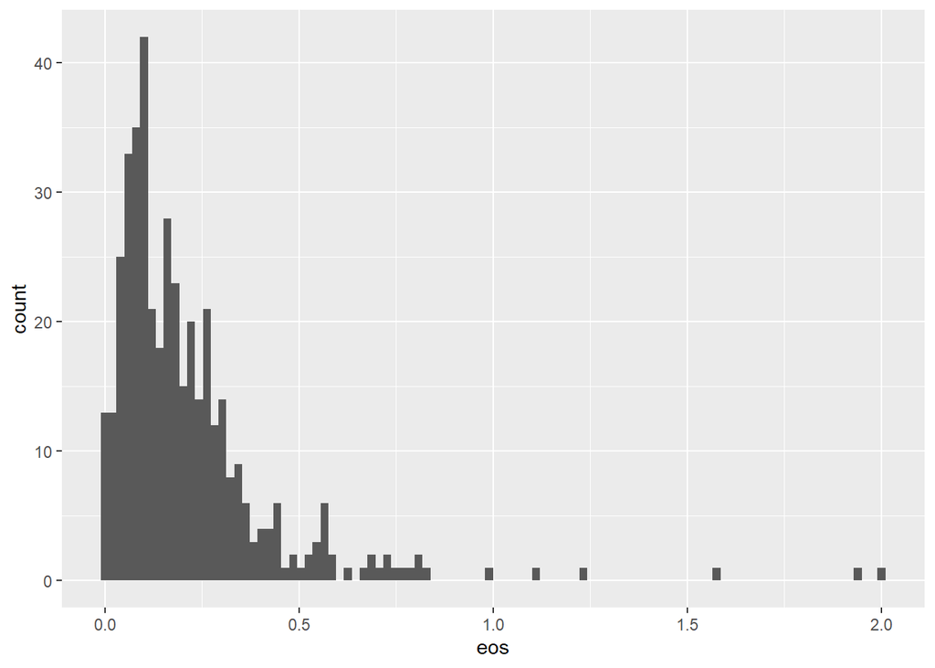

```r
ggplot(microb_dat_asthma) + geom_histogram(aes(eos), bins = 100)
```

```r
res_eos_expo_cont <- linear_res_fnc(expo = "eos",
                                    mets_list = feat_list,
                                    dat = "microb_dat_asthma",
                                    mets_info = "microb_mets_info",
                                    add_covar = " + Gender + bmi")
res_eos_expo_cont <- res_eos_expo_cont[, comparison := "eos_continous"] %>%
        setcolorder(., "comparison")
```

## 6.6. Continuous fev1

```r
microb_dat_asthma[, summary(fev1_prebd_pctpred)]
```

```
##    Min. 1st Qu.  Median    Mean 3rd Qu.    Max.    NA's
##      29      73      90      87     102     129     252
```

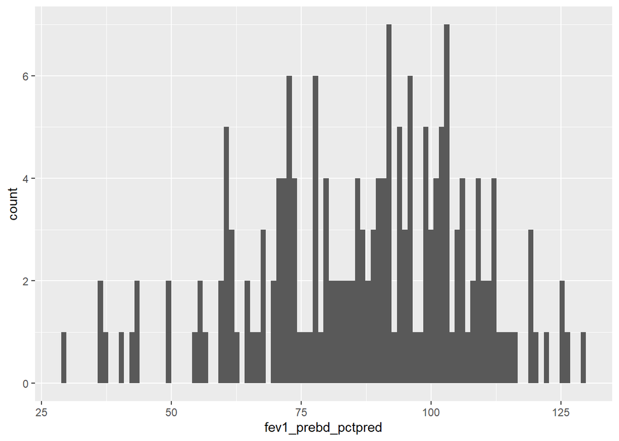

```r
ggplot(microb_dat_asthma) + geom_histogram(aes(fev1_prebd_pctpred), bins = 100)
```

```r
res_fev1_expo_cont <- linear_res_fnc(expo = "fev1_prebd_pctpred",
                                     mets_list = feat_list,
                                     dat = "microb_dat_asthma",
                                     mets_info = "microb_mets_info",
                                     add_covar = " + Gender + bmi")
res_fev1_expo_cont <- res_fev1_expo_cont[, comparison := "fev1_continous"] %>%
        setcolorder(., "comparison")

res_qt_asthmatics <- rbind(res_eos_expo_cont, res_fev1_expo_cont)
```

## 6.7. Continuous fvc

```r
microb_dat_asthma[, summary(fvc_prebd_pctpred)]
```

```
##    Min. 1st Qu.  Median    Mean 3rd Qu.    Max.    NA's
##   35.00   82.00   93.00   92.22  104.25  129.00     252
```

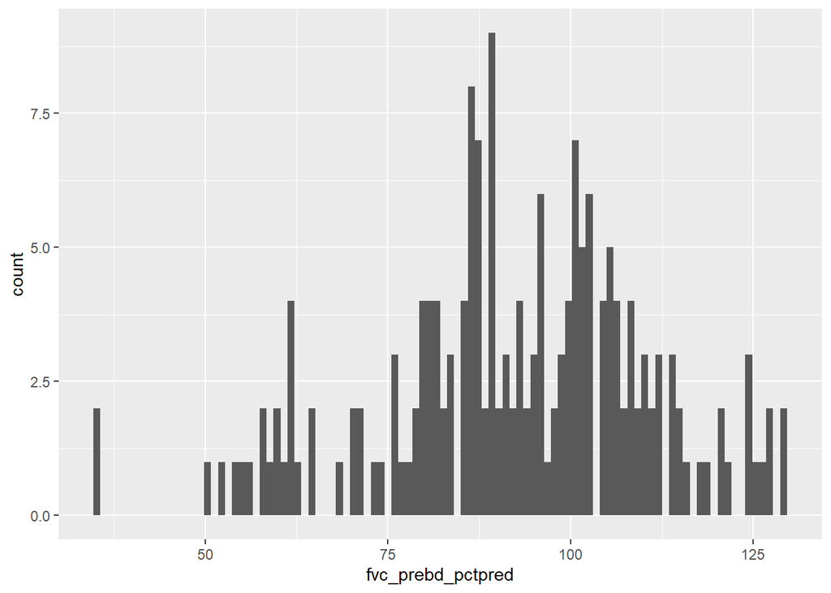

```r
ggplot(microb_dat_asthma) + geom_histogram(aes(fvc_prebd_pctpred), bins = 100)
```

```r
res_fvc_expo_cont <- linear_res_fnc(expo = "fvc_prebd_pctpred",
                                    mets_list = feat_list,
                                    dat = "microb_dat_asthma",
                                    mets_info = "microb_mets_info",
                                    add_covar = " + Gender + bmi")
res_fvc_expo_cont <- res_fvc_expo_cont[, comparison := "fvc_continous"] %>%
        setcolorder(., "comparison")

res_qt_asthmatics <- rbind(res_qt_asthmatics, res_fvc_expo_cont)
```

## 6.8. Continuous fev1/fvc

```r
microb_dat_asthma[, summary(fev1fvc_prebd_pctpred)]
```

```
##    Min. 1st Qu.  Median    Mean 3rd Qu.    Max.    NA's
##  0.5577  0.8904  0.9654  0.9414  1.0203  1.1852     252
```

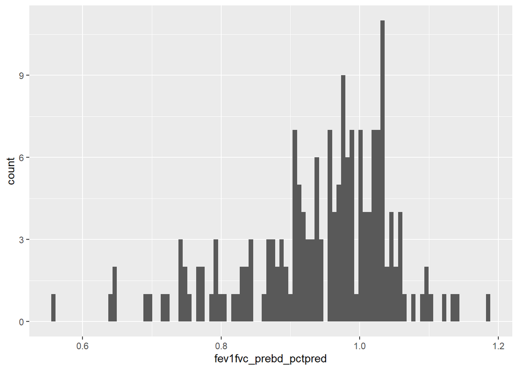

```r
ggplot(microb_dat_asthma) + geom_histogram(aes(fev1fvc_prebd_pctpred), bins = 100)
```

```r
res_fev1fvc_expo_cont <- linear_res_fnc(expo = "fev1fvc_prebd_pctpred",
                                        mets_list = feat_list,
                                        dat = "microb_dat_asthma",
                                        mets_info = "microb_mets_info",
                                        add_covar = " + Gender + bmi")
res_fev1fvc_expo_cont <- res_fev1fvc_expo_cont[, comparison := "fev1fvc_continous"] %>%
        setcolorder(., "comparison")

res_qt_asthmatics <- rbind(res_qt_asthmatics, res_fev1fvc_expo_cont)
```

## 6.9. Continuous neutrophil

```r
microb_dat_asthma[, summary(neut)]
```

```
##    Min. 1st Qu.  Median    Mean 3rd Qu.    Max.    NA's
##   0.510   3.408   4.285   4.825   5.665  15.550       8
```

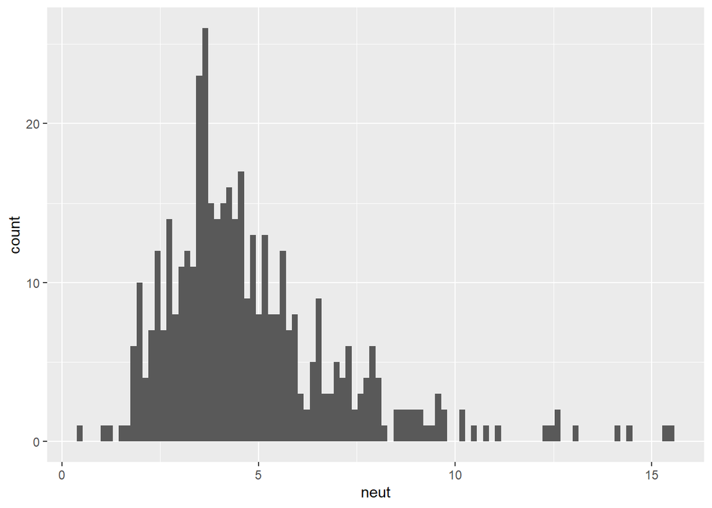

```r
ggplot(microb_dat_asthma) + geom_histogram(aes(neut), bins = 100)
```

```r
res_neut_expo_cont <- linear_res_fnc(expo = "neut",
                                     mets_list = feat_list,
                                     dat = "microb_dat_asthma",
                                     mets_info = "microb_mets_info",
                                     add_covar = " + Gender + bmi")
res_neut_expo_cont <- res_neut_expo_cont[, comparison := "neut_continous"] %>%
        setcolorder(., "comparison")

res_qt_asthmatics <- rbind(res_qt_asthmatics, res_neut_expo_cont)


## Save results

saveRDS(res_qt_asthmatics, file = here(res_dir, "res_qt_asthmatics_microb.rds"))

datatable(res_qt_asthmatics[, comparison := as.factor(comparison)], filter = "top") %>%
        formatSignif(columns = c("beta", "pval", "pct_na_met", "se", "tval"), digits = sig_digits)
```

|  | comparison | feature | expo | beta | pval | tentative_annotation | wo_ms2 | med_feat | rt_min | mz | platform | pct_na_met | se | tval | SUB_PATHWAY | cv | skewness_post |
| --- | --- | --- | --- | --- | --- | --- | --- | --- | --- | --- | --- | --- | --- | --- | --- | --- | --- |
| 1 | eos_continous | trypkynu_ratio | eos | -8.79371180174104 | 0.000161222458524366 |  |  |  |  |  |  |  | 2.30930522730326 | -3.80794695208397 |  |  |  |
| 2 | eos_continous | X66 | eos | -1.75385804933617 | 0.0036011929669751 | tryptophan | 0 | 0 |  |  | Targeted-microbial-mets | 0.000888888888888889 | 0.599036650386133 | -2.92779756999116 | Tryptophan Metabolism |  |  |
| 3 | eos_continous | X41 | eos | 0.0649814313020735 | 0.00835098503245652 | kynurenine | 0 | 0 |  |  | Targeted-microbial-mets | 0.000888888888888889 | 0.0245193687356431 | 2.65020816819039 | Tryptophan Metabolism |  |  |
| 4 | eos_continous | X39 | eos | -0.00878179460819461 | 0.0794798288119827 | isovalerate | 0 | 0 |  |  | Targeted-microbial-mets | 0 | 0.00499528143831425 | -1.7580179849002 | Short Chain Fatty Acids |  |  |
| 5 | eos_continous | X32 | eos | -0.0226837623599915 | 0.088660710089914 | indole-3-lactate | 0 | 0 |  |  | Targeted-microbial-mets | 0 | 0.0132925395006384 | -1.70650328772032 | Tryptophan Metabolism |  |  |
| 6 | eos_continous | X43 | eos | -2.26115653543931 | 0.0894894451367804 | lysine | 0 | 0 |  |  | Targeted-microbial-mets | 0 | 1.328474891848 | -1.7020694552186 | polyamine metabolism |  |  |
| 7 | eos_continous | X34 | eos | -0.073263223634349 | 0.102280654567181 | indoleacetate | 0 | 0 |  |  | Targeted-microbial-mets | 0 | 0.0447406974655687 | -1.63750741013214 | Tryptophan Metabolism |  |  |
| 8 | eos_continous | X10 | eos | -0.022398049972775 | 0.102343461988178 | 4-hydroxyphenyllactate | 0 | 0 |  |  | Targeted-microbial-mets | 0 | 0.0136806481029037 | -1.63720679051901 | Phenylalanine and Tyrosine Metabolism |  |  |
| 9 | eos_continous | X62 | eos | 0.0194602859709544 | 0.102364474168169 | serotonin | 0 | 0 |  |  | Targeted-microbial-mets | 0.00177777777777778 | 0.0118870024198181 | 1.63710625132119 | Tryptophan Metabolism |  |  |
| 10 | eos_continous | X54 | eos | -0.806924522656129 | 0.108756333666967 | phenylalanine | 0 | 0 |  |  | Targeted-microbial-mets | 0 | 0.502050192824423 | -1.60725866494852 | Phenylalanine and Tyrosine Metabolism |  |  |

[output cut: 265 more lines]

```r
fwrite(res_qt_asthmatics[grepl("trypkyn", feature) | tentative_annotation %in% c("tryptophan", "kynurenine"), ],
       file = here(res_dir, "tryp_kynu_quant_traits_in_asthmatics.csv"))


## Neut Q4 vs Q1 and kynurenine

microb_dat_asthma[, neut_q := cut2(neut, g = 4)]
microb_dat_asthma[, .N, neut_q]
```

```
##          neut_q   N
## 1: [0.51, 3.41) 106
## 2: [3.41, 4.29) 106
## 3: [5.71,15.55] 106
## 4: [4.29, 5.71) 106
## 5:         <NA>   8
```

```r
lm(X41 ~ neut_q + Age + race + Gender + bmi, # Kynurenine
   data = microb_dat_asthma[neut_q %in% c('[0.51, 3.41)', '[5.71,15.55]'), ]) %>% summary()
```

```
##
## Call:
## lm(formula = X41 ~ neut_q + Age + race + Gender + bmi, data = microb_dat_asthma[neut_q %in%
##     c("[0.51, 3.41)", "[5.71,15.55]"), ])
##
## Residuals:
##      Min       1Q   Median       3Q      Max
## -0.20132 -0.07301 -0.02196  0.04739  0.48917
##
## Coefficients:
##                     Estimate Std. Error t value Pr(>|t|)
## (Intercept)         0.138549   0.049887   2.777  0.00599 **
## neut_q[5.71,15.55] -0.012171   0.016686  -0.729  0.46658
## Age                 0.001334   0.000516   2.586  0.01041 *
## raceOther           0.009021   0.038523   0.234  0.81509
## raceWhite           0.034959   0.032387   1.079  0.28167
## GenderM             0.038901   0.019841   1.961  0.05128 .
## bmi                 0.004282   0.001008   4.248 3.27e-05 ***
## ---
## Signif. codes:  0 '***' 0.001 '**' 0.01 '*' 0.05 '.' 0.1 ' ' 1
##
## Residual standard error: 0.1148 on 205 degrees of freedom
## Multiple R-squared:  0.1477, Adjusted R-squared:  0.1227
## F-statistic:  5.92 on 6 and 205 DF,  p-value: 1.016e-05
```

```r
lm(X66 ~ neut_q + Age + race + Gender + bmi, # Tryptophan
   data = microb_dat_asthma[neut_q %in% c('[0.51, 3.41)', '[5.71,15.55]'), ]) %>% summary()
```

```
##
## Call:
## lm(formula = X66 ~ neut_q + Age + race + Gender + bmi, data = microb_dat_asthma[neut_q %in%
##     c("[0.51, 3.41)", "[5.71,15.55]"), ])
##
## Residuals:
##     Min      1Q  Median      3Q     Max
## -7.9669 -1.9035 -0.3153  1.8057  9.8078
##
## Coefficients:
##                    Estimate Std. Error t value Pr(>|t|)
## (Intercept)        14.11954    1.24749  11.318  < 2e-16 ***
## neut_q[5.71,15.55] -0.44080    0.41724  -1.056  0.29200
## Age                -0.02121    0.01290  -1.643  0.10185
## raceOther          -0.63000    0.96332  -0.654  0.51385
## raceWhite          -0.21880    0.80987  -0.270  0.78730
## GenderM             1.44502    0.49616   2.912  0.00398 **
## bmi                -0.03818    0.02521  -1.515  0.13137
## ---
## Signif. codes:  0 '***' 0.001 '**' 0.01 '*' 0.05 '.' 0.1 ' ' 1
##
## Residual standard error: 2.871 on 205 degrees of freedom
## Multiple R-squared:  0.07138,    Adjusted R-squared:  0.0442
## F-statistic: 2.626 on 6 and 205 DF,  p-value: 0.01785
```

```r
lm(trypkynu_ratio ~ neut_q + Age + race + Gender + bmi, # Tryptophan/kynurenine ratio
   data = microb_dat_asthma[neut_q %in% c('[0.51, 3.41)', '[5.71,15.55]'), ]) %>% summary()
```

```
##
## Call:
## lm(formula = trypkynu_ratio ~ neut_q + Age + race + Gender +
##     bmi, data = microb_dat_asthma[neut_q %in% c("[0.51, 3.41)",
##     "[5.71,15.55]"), ])
##
## Residuals:
##     Min      1Q  Median      3Q     Max
## -30.560  -6.796  -1.010   5.636  42.216
##
## Coefficients:
##                    Estimate Std. Error t value Pr(>|t|)
## (Intercept)        62.43616    4.84158  12.896  < 2e-16 ***
## neut_q[5.71,15.55]  0.64906    1.61935   0.401 0.688974
## Age                -0.18539    0.05008  -3.702 0.000275 ***
## raceOther          -2.09667    3.73871  -0.561 0.575546
## raceWhite          -5.10325    3.14315  -1.624 0.105996
## GenderM             0.17844    1.92562   0.093 0.926261
## bmi                -0.47566    0.09783  -4.862 2.31e-06 ***
## ---
## Signif. codes:  0 '***' 0.001 '**' 0.01 '*' 0.05 '.' 0.1 ' ' 1
##
## Residual standard error: 11.14 on 205 degrees of freedom
## Multiple R-squared:  0.1837, Adjusted R-squared:  0.1598
## F-statistic:  7.69 on 6 and 205 DF,  p-value: 1.829e-07
```